# Tet2_Analysis

gbolden

4/14/2025

```r
#manage a data.frame/tibble
library(tidyverse)
library(DESeq2)
library(postprocess)
library(clusterProfiler)
library(biomaRt)
library(AnnotationDbi)
library(org.Mm.eg.db)
```

5. Tet2_wildtype_CUT&TAG_rep1, SRR21586222
6. Tet2_knockout_CUT&TAG_rep1, SRR21586221

## SnakeMake Pre-Processing Commands

UNIX commands (Ran on the Umich Great Lakes Cluster)

Before running Ensure your directory tree looks similar to the example below

snakemake/ |── Snakefile # Main workflow |── config/ │ └── config.yaml # Parameters, sample info, etc. |─ envs/ │ └── chip_pipeline.yaml # Conda environments |── scripts/ │ ├── custom_analysis.R # R analysis scripts │ └── helper_functions.py # Python helpers |── data/ │ └── chip_data/ | # Raw fastq files, e.g., SRRxxxx_1.fastq |── chip_pipleine/ └── SnakeFile/ #SnakeFile to be called

Repeat this structure for RNA-Seq Pre-Processing Pipeline

You should alread have conda installed, else: https://docs.conda.io/projects/conda/en/stable/user-guide/install/linux.html Install SnakeMake if you have not already # Linux wget https://repo.anaconda.com/miniconda/Miniconda3-latest-Linux-x86_64.sh bash Miniconda3-latest-Linux-x86_64.sh

# macOS

wget https://repo.anaconda.com/miniconda/Miniconda3-latest-MacOSX-x86_64.sh bash Miniconda3-latest-MacOSX-x86_64.sh

Creat a Cona Env conda create -n snakemake-env -c conda-forge -c bioconda snakemake conda activate snakemake-env

Make your environments conda config –set channel_priority strict or that does not work channel_priority flexible

cd to the env folder conda env create –name rna_pipeline –file rna_pipeline.yaml conda env create –name chip_pipeline –file chip_pipeline.yaml

Make Sure you have the paired-end Sequences (ChIP/CUT&TAG, RNA-seq) into their seperate folders under ./data/chip_data, and ./data/rna_data

conda activate one of the environments

conda activate rna_pipeline or conda activate rna_pipeline ### SnakeMake Commands

cd to the respective pre-processing folder

run using snakemake –dry-run to check the pipeline is working

snakemake –cores 32 # for the real datasets

As of 4/11/2025 we must use some other datasets until the real ones are ready

We are using a real dataset but not the one are planning.

I then had to create a count matrix for DeSeq2

RNA-Seq Analysis

need to reformat the rnaseqdat grab the merged counts tsv

```r
tet2_wt_rp1 <- read_tsv("./SRR21586232 RNAseq WT/merged_counts_tet2wt_rep1.txt", comment = "#")
tet2_wt_rp2 <- read_tsv("./SRR21586232 RNAseq WT/merged_counts_tet2wt_rep2.txt", comment = "#")
tet2_ko_rp1 <- read_tsv("./SRR21586226 RNAseq KO/merged_counts_tet2ko_rep1.txt", comment = "#")
tet2_ko_rp2 <- read_tsv("./SRR21586226 RNAseq KO/merged_counts_tet2ko_rep2.txt", comment = "#")
```

Reformating function for post process

```r
colnames(tet2_wt_rp1)[7] = "WT_rep1"
colnames(tet2_wt_rp2)[7] = "WT_rep2"
colnames(tet2_ko_rp1)[7] = "KO_rep1"
colnames(tet2_ko_rp2)[7] = "KO_rep2"
```

```r
WT_KO_rep1 <- left_join(tet2_wt_rp1, tet2_wt_rp2, by = "Geneid")
WT_KO_rep2 <- left_join(tet2_ko_rp1, tet2_ko_rp2, by = "Geneid")
tet2_RNASeq <- left_join(WT_KO_rep1, WT_KO_rep2, by = "Geneid") %>%
  dplyr::select("Geneid", "WT_rep1", "WT_rep2", "KO_rep1", "KO_rep2")
```

```r
tet2_RNASeq
```

```
## # A tibble: 49,997 × 5
##    Geneid WT_rep1 WT_rep2 KO_rep1 KO_rep2
##    <chr>    <dbl>   <dbl>   <dbl>   <dbl>
##  1 TrnP       463     485     338     247
##  2 TrnT         3      11       7       3
##  3 CYTB     47180   46485   55295   40037
##  4 TrnE         7      15       8      12
##  5 ND6      13740   17217   11029    9665
##  6 ND5      47490   50701   43956   31347
##  7 TrnL2      176     169      89      98
##  8 TrnS2      200     200     110      81
##  9 TrnH       303     297     184     156
## 10 ND4      21480   20958   20514   15908
## # ℹ 49,987 more rows
```

```r
countData <- as.matrix(tet2_RNASeq[ , -1])
rownames(countData) <- tet2_RNASeq[[1]]
colData <- data.frame(
  row.names = colnames(countData),
  condition = c("WT", "WT", "KO", "KO")
)
```

```r
dds <- DESeqDataSetFromMatrix(
  countData = countData,
  colData = colData,
  design = ~ condition
)
dds <- DESeq(dds)
normalized_counts <- counts(dds, normalized = TRUE)

results_table <- results(dds)

results_frame <- as.data.frame(results_table)
```

```r
Tet2_WTvKO <- tibble::rownames_to_column(results_frame, "GeneID")
Tet2_WTvKO
```

```
##                 GeneID     baseMean log2FoldChange      lfcSE          stat
## 1                 TrnP 3.768722e+02   4.781938e-01 0.21331711  2.241704e+00
## 2                 TrnT 6.038374e+00   3.073515e-01 1.38544684  2.218428e-01
## 3                 CYTB 4.729636e+04  -2.455906e-01 0.13051995 -1.881632e+00
## 4                 TrnE 1.058420e+01  -5.783493e-02 1.03107353 -5.609195e-02
## 5                  ND6 1.277475e+04   3.710090e-01 0.13898484  2.669421e+00
## 6                  ND5 4.300686e+04   1.662785e-01 0.13896221  1.196573e+00
## 7                TrnL2 1.299943e+02   6.612038e-01 0.30202985  2.189200e+00
## 8                TrnS2 1.438609e+02   8.461673e-01 0.30059811  2.814945e+00
## 9                 TrnH 2.301188e+02   5.982148e-01 0.23817718  2.511638e+00
## 10                 ND4 1.960464e+04  -1.429860e-04 0.11976323 -1.193906e-03
## 11                ND4L 3.498496e+01  -4.046793e-01 0.56096685 -7.213962e-01
## 12                TrnR 2.222060e+00   8.042871e-01 2.14773890  3.744809e-01
## 13                 ND3 3.588075e+01  -1.872363e-01 0.56180113 -3.332787e-01
## 14                TrnG 4.857295e-01  -2.467903e-01 4.83823768 -5.100830e-02
```

[output cut: 28558 more lines]

```r
library(postprocess)
```

```r
object <- deseq_filteration(tibble =  Tet2_WTvKO, file_name = "Tet2_WTvKO", pval_cutoff = 0.01, rev = FALSE)
```

```r
object <- unnest(as_tibble(object))
```

506 significantly differentially expressed genes when Tet is KOed

Read in WT ChIP-Seq data

```r
Tet2_WT_Peaks <- read_tsv("./SRR21586222 CUT&RUN WT/SRR21586222_ann_peaks.txt", comment = "#")
Tet2_WT_Peaks
```

```
## # A tibble: 61,305 × 19
##    PeakID (cmd=annotatePeaks.pl ../chi…¹ Chr    Start    End Strand `Peak Score`
##    <chr>                                 <chr>  <dbl>  <dbl> <chr>         <dbl>
##  1 SRR21586222_peak_22356                chr18 4.03e7 4.03e7 +             3083.
##  2 SRR21586222_peak_16557c               chr15 7.51e7 7.51e7 +             2479.
##  3 SRR21586222_peak_26121b               chr2  9.87e7 9.87e7 +             2400.
##  4 SRR21586222_peak_21540                chr18 3.01e6 3.01e6 +             1931.
##  5 SRR21586222_peak_6938                 chr11 5.41e7 5.41e7 +             1466
##  6 SRR21586222_peak_10699                chr12 9.71e7 9.71e7 +              860.
##  7 SRR21586222_peak_45544                chr9  3.53e7 3.53e7 +              827.
##  8 SRR21586222_peak_3255                 chr1  1.95e8 1.95e8 +              779.
##  9 SRR21586222_peak_3079                 chr1  1.83e8 1.83e8 +              719.
## 10 SRR21586222_peak_28042b               chr3  8.25e6 8.25e6 +              655.
## # ℹ 61,295 more rows
## # ℹ abbreviated name:
## #   ¹`PeakID (cmd=annotatePeaks.pl ../chip_output/macs2_output/SRR21586222_summits.bed mm10 -gtf ../chip_output/tmp/mm10.ncbiRefSeq.gtf)`
## # ℹ 13 more variables: `Focus Ratio/Region Size` <lgl>, Annotation <chr>,
## #   `Detailed Annotation` <chr>, `Distance to TSS` <dbl>,
## #   `Nearest PromoterID` <chr>, `Entrez ID` <chr>, `Nearest Unigene` <chr>,
## #   `Nearest Refseq` <lgl>, `Nearest Ensembl` <lgl>, `Gene Name` <chr>, …
```

```r
Tet2_WT_Peaks <- tibble(Tet2_WT_Peaks) %>%
  dplyr::select("Chr", "Start", "End", "Entrez ID")
colnames(Tet2_WT_Peaks)[4] = "GeneID"
```

```r
Tet2_WT_Peaks
```

```
## # A tibble: 61,305 × 4
##    Chr       Start       End GeneID
##    <chr>     <dbl>     <dbl> <chr>
##  1 chr18  40308223  40308223 Gm31087
##  2 chr15  75086776  75086776 Gm52219
##  3 chr2   98667065  98667065 Gm33780
##  4 chr18   3005804   3005804 Vmn1r-ps151
##  5 chr11  54140286  54140286 Gm12223
##  6 chr12  97061570  97061570 Gm6863
##  7 chr9   35305442  35305442 Gm33838
##  8 chr1  195241716 195241716 Gm29726
##  9 chr1  183299361 183299361 Brox
## 10 chr3    8245904   8245904 Gm7103
## # ℹ 61,295 more rows
```

```r
Tet2_RNAChIP <- merge(Tet2_WT_Peaks, object, by = "GeneID") %>%             dplyr::select(-c("file_name"))
```

```r
Tet2_RNAChIP_unique <- Tet2_RNAChIP %>%
  distinct(GeneID, .keep_all = TRUE) %>%
  arrange(desc(log2FoldChange))
Tet2_RNAChIP_unique
```

```
##            GeneID   Chr     Start       End     baseMean log2FoldChange
## 1   E130018N17Rik  chr2 168154649 168154649    15.385467       4.172158
## 2         Grin1os  chr2  25305198  25305198    22.654261       3.462307
## 3           Fhad1  chr4 142014980 142014980    29.706919       3.035894
## 4          Slc4a9 chr18  36525510  36525510    32.851286       2.836397
## 5           Grin1  chr2  25323916  25323916   407.908624       2.799823
## 6          Nkx6-3  chr8  23152585  23152585    88.133851       2.611248
## 7         Ccdc113  chr8  95528699  95528699    29.610592       2.556524
## 8         Gm42327  chr4 135046858 135046858    18.139996       2.519087
## 9            Pygl chr12  70227576  70227576   134.311027       2.477932
## 10        Gm15283 chr12  73949855  73949855    27.040527       2.399171
## 11          Ddx60  chr8  61964498  61964498    40.883712       2.278049
## 12        Dnajb13  chr7 100514733 100514733    28.296612       2.272067
## 13         Crtac1 chr19  42322258  42322258   176.323653       2.155173
## 14           Aire chr10  78037424  78037424  1075.536433       2.143774
```

[output cut: 521 more lines]

```r
#this function needs to be generalized. How? Need to take a page out of the clusterprofiler
mmu_entrezid_to_genename <- function(entrez_vector) {
  #requires both of these packages to run
  #require("biomaRt")
  #require("org.Mmu.eg.db")
  #connect to the Ensembl database for Mmu
  ensembl = useMart("ensembl", dataset = "mmusculus_gene_ensembl")
  #getting the corresponding Entrez Gene IDs
  entrezid_genename_df <- getBM(attributes = c("external_gene_name", "entrezgene_id"), filters = "external_gene_name", values = entrez_vector, mart = ensembl)
  #return both the df and the vector
  return(entrezid_genename_df)
}
```

```r
entrez_ids <- mmu_entrezid_to_genename(Tet2_RNAChIP_unique$GeneID)
entrez_ids
```

```
##     external_gene_name entrezgene_id
## 1                 Cdh2         12558
## 2                 Dsc2         13506
## 3                Mep1b         17288
## 4               Piezo2        667742
## 5                Greb1        268527
## 6               Gabra3         14396
## 7                Wnt8a         20890
## 8                 Zhx2        387609
## 9              Cysltr1         58861
## 10               Lpar4         78134
## 11                Cap2         67252
## 12            Tnfrsf19         29820
## 13              Lratd2        399603
## 14              Ccdc80         67896
```

[output cut: 247 more lines]

Run the the genenames through the enrichGO from ClusterProfiler

```r
key <- enrichGO(
  entrez_ids$entrezgene_id,
  "org.Mm.eg.db",
  ont = "ALL",
  pvalueCutoff = 0.05,
  pAdjustMethod = "BH"
)
```

```r
key@result
```

```
##            ONTOLOGY         ID
## GO:0001667       BP GO:0001667
## GO:0032970       BP GO:0032970
## GO:0006816       BP GO:0006816
## GO:2000177       BP GO:2000177
## GO:0007015       BP GO:0007015
## GO:0032231       BP GO:0032231
## GO:0062009       BP GO:0062009
## GO:0007162       BP GO:0007162
## GO:0060485       BP GO:0060485
## GO:0032102       BP GO:0032102
## GO:0031589       BP GO:0031589
## GO:0030900       BP GO:0030900
## GO:0016358       BP GO:0016358
## GO:0050678       BP GO:0050678
## GO:0046660       BP GO:0046660
## GO:0003007       BP GO:0003007
## GO:0007411       BP GO:0007411
## GO:0051017       BP GO:0051017
## GO:0097485       BP GO:0097485
## GO:0007416       BP GO:0007416
## GO:0061572       BP GO:0061572
## GO:0048771       BP GO:0048771
## GO:0016055       BP GO:0016055
## GO:0032956       BP GO:0032956
## GO:0031346       BP GO:0031346
## GO:0061351       BP GO:0061351
## GO:0098742       BP GO:0098742
## GO:0021537       BP GO:0021537
## GO:0050878       BP GO:0050878
## GO:0010812       BP GO:0010812
## GO:0043030       BP GO:0043030
## GO:0030198       BP GO:0030198
## GO:0045229       BP GO:0045229
## GO:0043062       BP GO:0043062
## GO:0035883       BP GO:0035883
## GO:0051098       BP GO:0051098
## GO:0045137       BP GO:0045137
## GO:0001894       BP GO:0001894
## GO:0060249       BP GO:0060249
```

[output cut: 5585 more lines]

```
## GO:0005109     4
## GO:0016835     5
## GO:0016705     8
## GO:0005125     8
## GO:0003924     9
## GO:0046943     7
## GO:0005342     7
## GO:0005216    11
## GO:0016836     4
## GO:0045499     3
## GO:0008509     6
## GO:0005253     5
## GO:0051020     9
## GO:0030507     3
## GO:0008514     8
```

```r
Tet2_RNAChIP_unique
```

```
##            GeneID   Chr     Start       End     baseMean log2FoldChange
## 1   E130018N17Rik  chr2 168154649 168154649    15.385467       4.172158
## 2         Grin1os  chr2  25305198  25305198    22.654261       3.462307
## 3           Fhad1  chr4 142014980 142014980    29.706919       3.035894
## 4          Slc4a9 chr18  36525510  36525510    32.851286       2.836397
## 5           Grin1  chr2  25323916  25323916   407.908624       2.799823
## 6          Nkx6-3  chr8  23152585  23152585    88.133851       2.611248
## 7         Ccdc113  chr8  95528699  95528699    29.610592       2.556524
## 8         Gm42327  chr4 135046858 135046858    18.139996       2.519087
## 9            Pygl chr12  70227576  70227576   134.311027       2.477932
## 10        Gm15283 chr12  73949855  73949855    27.040527       2.399171
## 11          Ddx60  chr8  61964498  61964498    40.883712       2.278049
## 12        Dnajb13  chr7 100514733 100514733    28.296612       2.272067
## 13         Crtac1 chr19  42322258  42322258   176.323653       2.155173
## 14           Aire chr10  78037424  78037424  1075.536433       2.143774
```

[output cut: 521 more lines]

```r
enrichgo_result <- key@result
chosen_desc <- "cell fate commitment"
ensemble_dataset <- "mmusculus_gene_ensembl"
deseq2_table <- Tet2_RNAChIP_unique
```

enrichr_unpacking

```r
enrichgo_unpack  <- enrichgo_unpack(deseq2_table,
                                    enrichgo_result,
                                    chosen_desc,
                                    ensemble_dataset)
```

```r
enrichgo_unpack
```

```
## # A tibble: 19 × 13
##    gene_desc       entrezgene_id external_gene_name Chr    Start    End baseMean
##    <chr>           <chr>         <chr>              <chr>  <dbl>  <dbl>    <dbl>
##  1 cell fate comm… 20890         Wnt8a              chr18 3.45e7 3.45e7     79.0
##  2 cell fate comm… 22418         Wnt5a              chr14 2.85e7 2.85e7     73.0
##  3 cell fate comm… 232077        Foxi3              chr6  7.10e7 7.10e7    262.
##  4 cell fate comm… 12394         Runx1              chr16 9.27e7 9.27e7     92.8
##  5 cell fate comm… 17341         Bhlha15            chr5  1.44e8 1.44e8    103.
##  6 cell fate comm… 22416         Wnt3a              chr11 5.93e7 5.93e7     56.8
##  7 cell fate comm… 74561         Nkx6-3             chr8  2.32e7 2.32e7     88.1
##  8 cell fate comm… 21808         Tgfb2              chr1  1.87e8 1.87e8     52.5
##  9 cell fate comm… 14432         Gap43              chr16 4.24e7 4.24e7    287.
## 10 cell fate comm… 50523         Lats2              chr14 5.77e7 5.77e7    120.
## 11 cell fate comm… 18012         Neurod1            chr2  7.95e7 7.95e7    439.
## 12 cell fate comm… 18508         Pax6               chr2  1.06e8 1.06e8    116.
## 13 cell fate comm… 22431         Wt1                chr2  1.05e8 1.05e8    105.
## 14 positive regul… 22416         Wnt3a              chr11 5.93e7 5.93e7     56.8
## 15 positive regul… 18508         Pax6               chr2  1.06e8 1.06e8    116.
## 16 muscle cell fa… 22416         Wnt3a              chr11 5.93e7 5.93e7     56.8
## 17 muscle cell fa… 22431         Wt1                chr2  1.05e8 1.05e8    105.
## 18 cardiac cell f… 22416         Wnt3a              chr11 5.93e7 5.93e7     56.8
## 19 cardiac cell f… 22431         Wt1                chr2  1.05e8 1.05e8    105.
## # ℹ 6 more variables: log2FoldChange <dbl>, FinalFC <dbl>, lfcSE <dbl>,
## #   stat <dbl>, pvalue <dbl>, padj <dbl>
```

Visualization DotPlot Can toggle the pvalue cutoff The type of graph priority (‘Count’, ‘pvalue’) The title of the graph and the file_name output

[figure not shown]

```
##
## [[2]]
## [1] "file_name"
```

```r
gsea_dotplot(enrichgo_result, 0.05, 'Count', 10, "Top 10 DE, BP at Tet2KO", "file_name")
```

Visual Volcano Plot

```r
unique <- TRUE
lower_xlim <- -8
upper_xlim <- 8
step <- 2
gsea_results <- enrichgo_unpack
```

Current Arguments of Visual plot upper_xlim, lower_xlim upper ylim X-axis-step set unique genes?: does the researcher care weather or not the same genes listed under different annotations shold stay on the volcano plot

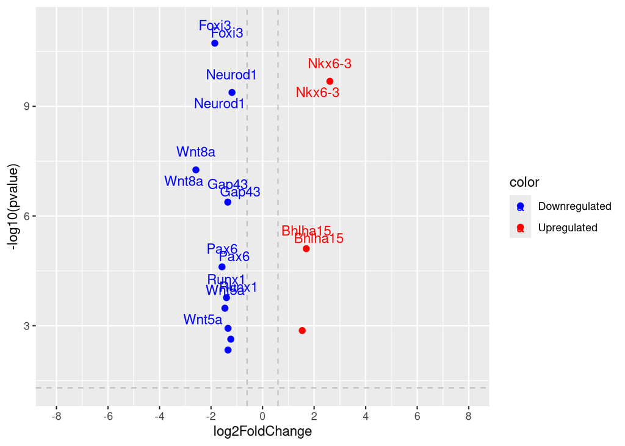

```
##
## [[2]]
## # A tibble: 13 × 15
##    gene_desc       entrezgene_id external_gene_name Chr    Start    End baseMean
##    <chr>           <chr>         <chr>              <chr>  <dbl>  <dbl>    <dbl>
##  1 cell fate comm… 232077        Foxi3              chr6  7.10e7 7.10e7    262.
##  2 cell fate comm… 74561         Nkx6-3             chr8  2.32e7 2.32e7     88.1
##  3 cell fate comm… 18012         Neurod1            chr2  7.95e7 7.95e7    439.
##  4 cell fate comm… 20890         Wnt8a              chr18 3.45e7 3.45e7     79.0
##  5 cell fate comm… 14432         Gap43              chr16 4.24e7 4.24e7    287.
##  6 cell fate comm… 17341         Bhlha15            chr5  1.44e8 1.44e8    103.
##  7 cell fate comm… 18508         Pax6               chr2  1.06e8 1.06e8    116.
##  8 cell fate comm… 12394         Runx1              chr16 9.27e7 9.27e7     92.8
##  9 cell fate comm… 22418         Wnt5a              chr14 2.85e7 2.85e7     73.0
## 10 cell fate comm… 22431         Wt1                chr2  1.05e8 1.05e8    105.
## 11 cell fate comm… 22416         Wnt3a              chr11 5.93e7 5.93e7     56.8
## 12 cell fate comm… 50523         Lats2              chr14 5.77e7 5.77e7    120.
## 13 cell fate comm… 21808         Tgfb2              chr1  1.87e8 1.87e8     52.5
## # ℹ 8 more variables: log2FoldChange <dbl>, FinalFC <dbl>, lfcSE <dbl>,
## #   stat <dbl>, pvalue <dbl>, padj <dbl>, color <chr>, delabel <chr>
```

```r
#possible arguments
# upper_xlim, lower_xlim
# upper ylim
# X-axis-incrment
# set unique genes?
gsea_volplot(gsea_results, unique = TRUE, lower_xlim = -8, upper_xlim = 8 , step = 2)
```

Update: extract bed file and run MEME